# Pemodelan ARIMA Harga Penutupan Saham NSE

Praktikum Metode Peramalan Deret Waktu (MPDW)

1 Oktober 2026

# 1 Pendahuluan

Laporan ini membangun model **ARIMA** untuk data harga penutupan saham NSE harian dengan tahapan: (1) pembagian data latih dan uji, (2) uji kestasioneran dalam rataan dan ragam, (3) penanganan ketidakstasioneran, (4) identifikasi model potensial, (5) pendugaan parameter, uji signifikansi, dan AIC, (6) analisis sisaan, (7) uji *overfitting*, serta (8) peramalan.

# 2 Data

File sumber menyimpan semua baris dalam **satu kolom teks yang dipisahkan koma** (tanggal diikuti harga banyak saham), dan nama kode saham tidak tersedia. Oleh karena itu data dipecah terlebih dahulu, lalu **satu saham dipilih lewat nomor kolomnya** (`kolom_saham`). Ubah nilai tersebut bila ingin memodelkan saham lain.

```r
kolom_saham <- 1    # nomor kolom saham (kolom 1 = saham pertama setelah kolom tanggal)
n_test      <- 244  # banyaknya amatan data uji (sekitar 1 tahun perdagangan)

mentah <- read_excel("NSE_Stock_Historical_price_data_dian.xlsx", col_names = FALSE,
                     col_types = "text", .name_repair = "minimal")
bagian <- strsplit(mentah[[1]], ",", fixed = TRUE)
tgl <- as.Date(sapply(bagian, `[`, 1))
x   <- as.numeric(sapply(bagian, function(v) v[kolom_saham + 1]))
stopifnot(!anyNA(x))   # saham yang dipilih harus lengkap (tanpa data kosong)

N <- length(x); n_train <- N - n_test
data.frame(Jumlah_amatan = N, Awal = min(tgl), Akhir = max(tgl),
           Min = round(min(x), 2), Maks = round(max(x), 2))
```

```
##   Jumlah_amatan       Awal      Akhir    Min    Maks
## 1          2444 2014-08-04 2024-07-05 370.65 3177.25
```

Data memuat **2444 amatan** (syarat minimal 500 amatan terpenuhi) berupa data harian hari bursa dari 2014-08-04 sampai 2024-07-05.

# 3 Pembagian Data Latih dan Uji

Data dibagi secara berurutan (tidak diacak) karena sifat deret waktu. Data uji diambil **244 amatan terakhir (sekitar 1 tahun perdagangan, 10%)**, sedangkan data latih adalah **2200 amatan pertama (90%)**. Proporsi ini dipilih karena ARIMA belajar dari pola jangka pendek, sehingga periode uji sekitar satu tahun sudah cukup untuk menilai ketepatan ramalan.

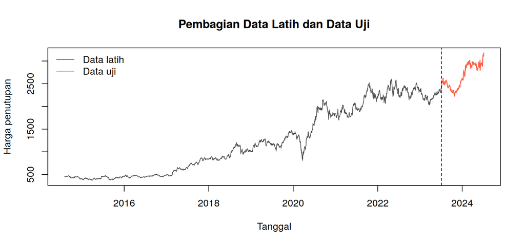

```r
train <- x[1:n_train];            tgl_train <- tgl[1:n_train]
test  <- x[(n_train + 1):N];      tgl_test  <- tgl[(n_train + 1):N]

plot(tgl, x, type = "l", col = "grey30", xlab = "Tanggal", ylab = "Harga penutupan",
     main = "Pembagian Data Latih dan Data Uji")
lines(tgl_test, test, col = "tomato", lwd = 1.5)
abline(v = tgl[n_train], lty = 2)
legend("topleft", c("Data latih", "Data uji"), col = c("grey30", "tomato"), lty = 1, bty = "n")
```

# 4 Kestasioneran Data Latih

## 4.1 Plot Deret Waktu dan ACF

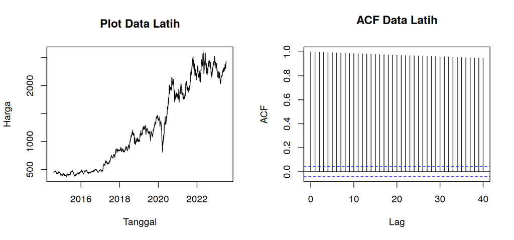

```r
par(mfrow = c(1, 2))
plot(tgl_train, train, type = "l", xlab = "Tanggal", ylab = "Harga", main = "Plot Data Latih")
acf(train, lag.max = 40, main = "ACF Data Latih")
```

```r
par(mfrow = c(1, 1))
```

Plot menunjukkan **tren naik** dan simpangan yang membesar saat harga tinggi. ACF turun sangat lambat (*tails off slowly*), ciri data tidak stasioner dalam rataan.

## 4.2 Uji ADF (Stasioneritas dalam Rataan)

H0: data tidak stasioner (terdapat akar unit); H1: data stasioner.

```r
adf_awal <- adf.test(train)
adf_awal
```

```
##
##  Augmented Dickey-Fuller Test
##
## data:  train
## Dickey-Fuller = -3.3428, Lag order = 13, p-value = 0.06327
## alternative hypothesis: stationary
```

p-value = 0.0633, sehingga kestasioneran dalam rataan **tidak terpenuhi (tak tolak H0)** pada taraf 5%.

## 4.3 Box-Cox (Stasioneritas dalam Ragam)

Data stasioner dalam ragam bila selang kepercayaan 95% bagi $\lambda$ **memuat angka 1**.

```r
cek_boxcox <- function(y, judul) {
  bc <- MASS::boxcox(y ~ 1, data = data.frame(y = y), lambda = seq(-3, 5, 0.01), plotit = FALSE)
  batas <- max(bc$y) - qchisq(0.95, 1) / 2
  ci <- range(bc$x[bc$y > batas])
  plot(bc$x, bc$y, type = "l", xlab = expression(lambda), ylab = "log-likelihood", main = judul)
  abline(h = batas, lty = 2, col = "red"); abline(v = ci, lty = 3, col = "blue")
  abline(v = 1, col = "darkgreen", lwd = 2)
  legend("topright", c("Batas 95%", "Selang kepercayaan", "lambda = 1"),
         col = c("red", "blue", "darkgreen"), lty = c(2, 3, 1), bty = "n", cex = 0.8)
  list(opt = bc$x[which.max(bc$y)], bawah = ci[1], atas = ci[2],
       memuat1 = round(ci[1], 2) <= 1 & round(ci[2], 2) >= 1)
}
```

```r
bc_awal <- cek_boxcox(train, "Box-Cox Data Latih (sebelum transformasi)")
```

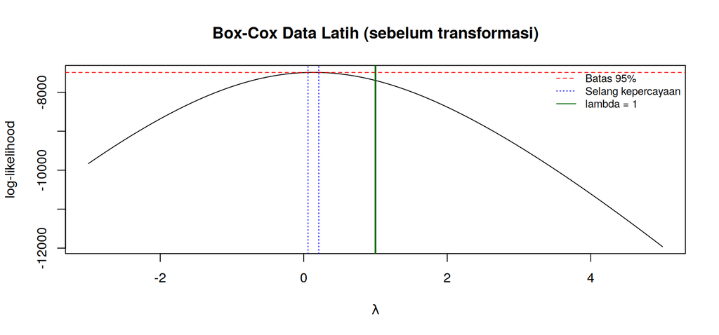

Nilai $\lambda$ optimum = 0.14 dengan selang kepercayaan 95% (0.06; 0.21). Selang tersebut **tidak memuat angka 1**, sehingga data **belum stasioner dalam ragam**.

# 5 Penanganan Ketidakstasioneran

## 5.1 Transformasi (Ragam)

Karena selang kepercayaan tidak memuat 1 dan $\lambda$ optimum mendekati 0, digunakan **transformasi logaritma natural** $Z_t = \ln(Y_t)$. Pemilihan ini juga didukung nilai $\lambda$ metode Guerrero = -0.07 yang mendekati 0.

```r
ltrain <- log(train)
bc_log <- cek_boxcox(ltrain, "Box-Cox Data Latih setelah Transformasi Log")
```

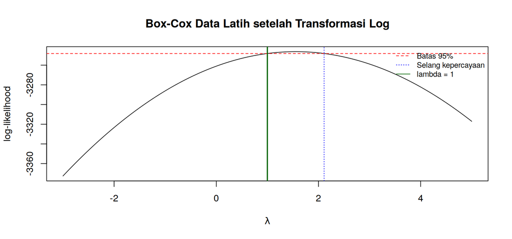

Setelah transformasi, selang kepercayaan 95% menjadi (1; 2.11), yang **memuat angka 1** (batas bawahnya tepat di sekitar 1), sehingga ragam dianggap **sudah stabil**.

## 5.2 Differencing (Rataan)

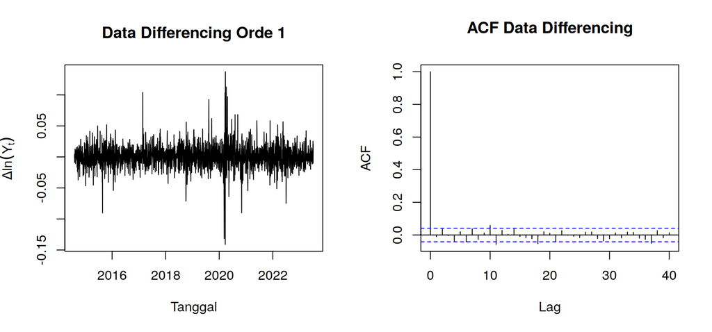

```r
adf_log <- adf.test(ltrain)
dlog <- diff(ltrain)                  # differencing orde 1 (d = 1)
adf_d1 <- adf.test(dlog)
par(mfrow = c(1, 2))
plot(tgl_train[-1], dlog, type = "l", xlab = "Tanggal", ylab = expression(Delta*ln(Y[t])),
     main = "Data Differencing Orde 1")
acf(dlog, lag.max = 40, main = "ACF Data Differencing")
```

```r
par(mfrow = c(1, 1))
adf_d1
```

```
##
##  Augmented Dickey-Fuller Test
##
## data:  dlog
## Dickey-Fuller = -11.756, Lag order = 13, p-value = 0.01
## alternative hypothesis: stationary
```

Uji ADF pada data hasil log (belum didiferensiasi) memberi p-value 0.0705 (**belum stasioner**). Setelah *differencing* orde 1, p-value = 0.0100 sehingga data **stasioner dalam rataan**. Dengan demikian $d = 1$ dan data hasil transformasi serta diferensiasi digunakan untuk identifikasi model.

# 6 Identifikasi Model Potensial

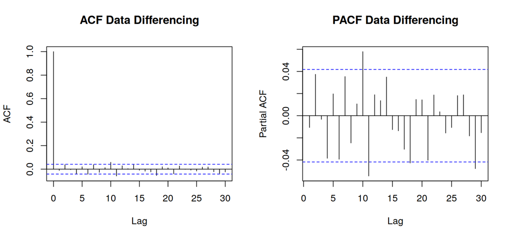

```r
par(mfrow = c(1, 2))
acf(dlog,  lag.max = 30, main = "ACF Data Differencing")
pacf(dlog, lag.max = 30, main = "PACF Data Differencing")
```

```r
par(mfrow = c(1, 1))
```

### 6.0.1 EACF

```r
# memakai TSA::eacf bila tersedia; jika tidak, memakai fungsi manual yang setara
if (requireNamespace("TSA", quietly = TRUE)) TSA::eacf(dlog, ar.max = 6, ma.max = 10) else
  eacf_manual(dlog, ar.max = 6, ma.max = 10)
```

```
##      0 1 2 3 4 5 6 7 8 9 10
## AR 0 o o o o o o o o o x x
## AR 1 x o o o o o o o o o o
## AR 2 x x o o o o o o o o o
## AR 3 x x o o o o o o o o o
## AR 4 x x o x o o o o o o o
## AR 5 x x o x o o o o o o o
## AR 6 x x x x o x o o o o o
```

# 7 Pendugaan Parameter, Uji Signifikansi, dan AIC

Parameter diuji dengan uji-z (H0: parameter = 0; tolak H0 jika p-value < 0,05). Model terbaik adalah model dengan **semua parameter signifikan dan AIC terkecil**.

```r
kandidat <- data.frame(p = c(0, 1, 0, 1, 2, 0, 0), q = c(0, 0, 1, 1, 0, 2, 0),
                       drift = c(rep(TRUE, 6), FALSE))   # model dari ACF/PACF/EACF dan tetangganya

hasil <- lapply(seq_len(nrow(kandidat)), function(i) {
  k <- kandidat[i, ]
  m <- Arima(ltrain, order = c(k$p, 1, k$q), include.drift = k$drift, method = "ML")
  ct <- tryCatch(suppressWarnings(coeftest(m)), error = function(e) NULL)
  pv <- if (is.null(ct)) numeric(0) else ct[, 4]
  lb20 <- Box.test(residuals(m), lag = 20, type = "Ljung-Box", fitdf = k$p + k$q)$p.value
  list(model = m, pv = pv, lb = lb20)
})

tabel <- data.frame(
  Model = sprintf("ARIMA(%d,1,%d)%s", kandidat$p, kandidat$q, ifelse(kandidat$drift, " + drift", "")),
  AIC = sapply(hasil, function(h) AIC(h$model)),
  BIC = sapply(hasil, function(h) BIC(h$model)),
  p_terbesar = sapply(hasil, function(h) if (length(h$pv)) suppressWarnings(max(h$pv)) else NA),
  Semua_signifikan = sapply(hasil, function(h) length(h$pv) == 0 || isTRUE(all(h$pv < 0.05))),
  p_LjungBox_sisaan = sapply(hasil, function(h) h$lb)
)
tabel <- tabel[order(tabel$AIC), ]; rownames(tabel) <- NULL
tabel$AIC <- round(tabel$AIC, 2); tabel$BIC <- round(tabel$BIC, 2); tabel$p_terbesar <- round(tabel$p_terbesar, 4); tabel$p_LjungBox_sisaan <- round(tabel$p_LjungBox_sisaan, 4)
knitr::kable(tabel, caption = "Perbandingan model kandidat (diurutkan menurut AIC; p_terbesar = p-value terbesar di antara parameter; p_LjungBox_sisaan = uji autokorelasi sisaan lag 20)")
```

Perbandingan model kandidat (diurutkan menurut AIC; p_terbesar = p-value terbesar di antara parameter; p_LjungBox_sisaan = uji autokorelasi sisaan lag 20)

| Model | AIC | BIC | p_terbesar | Semua_signifikan | p_LjungBox_sisaan |
| --- | --- | --- | --- | --- | --- |
| ARIMA(0,1,0) + drift | -11452.32 | -11440.93 | 0.0445 | TRUE | 0.0009 |
| ARIMA(0,1,2) + drift | -11451.86 | -11429.08 | 0.6453 | FALSE | 0.0016 |
| ARIMA(2,1,0) + drift | -11451.64 | -11428.86 | 0.6315 | FALSE | 0.0015 |
| ARIMA(1,1,0) + drift | -11450.57 | -11433.48 | 0.6186 | FALSE | 0.0008 |
| ARIMA(0,1,1) + drift | -11450.55 | -11433.47 | 0.6311 | FALSE | 0.0008 |
| ARIMA(0,1,0) | -11450.28 | -11444.58 | NA | TRUE | 0.0009 |
| ARIMA(1,1,1) + drift | -11449.26 | -11426.48 | 0.2493 | FALSE | 0.0007 |

```r
ok <- which(tabel$Semua_signifikan)
nama_terpilih <- tabel$Model[ok[1]]                       # AIC terkecil di antara model dengan semua parameter signifikan
idx <- match(nama_terpilih, sprintf("ARIMA(%d,1,%d)%s", kandidat$p, kandidat$q, ifelse(kandidat$drift, " + drift", "")))
p_f <- kandidat$p[idx]; q_f <- kandidat$q[idx]; dr_f <- kandidat$drift[idx]
fit <- hasil[[idx]]$model
fit
```

```
## Series: ltrain
## ARIMA(0,1,0) with drift
##
## Coefficients:
##       drift
##       8e-04
## s.e.  4e-04
##
## sigma^2 = 0.00032:  log likelihood = 5728.16
## AIC=-11452.32   AICc=-11452.32   BIC=-11440.93
```

```r
if (length(hasil[[idx]]$pv)) coeftest(fit)
```

```
##
## z test of coefficients:
##
##         Estimate Std. Error z value Pr(>|z|)
## drift 0.00076762 0.00038198  2.0096  0.04447 *
## ---
## Signif. codes:  0 '***' 0.001 '**' 0.01 '*' 0.05 '.' 0.1 ' ' 1
```

**Model terpilih: ARIMA(0,1,0) + drift** (AIC = -11452.32). Model ini memiliki seluruh parameter signifikan dan AIC terkecil di antara model yang parameternya signifikan semua. Pada skala asli, model ini berarti log harga mengikuti *random walk* dengan kenaikan rata-rata harian sekitar 0.077%.

# 8 Analisis Sisaan

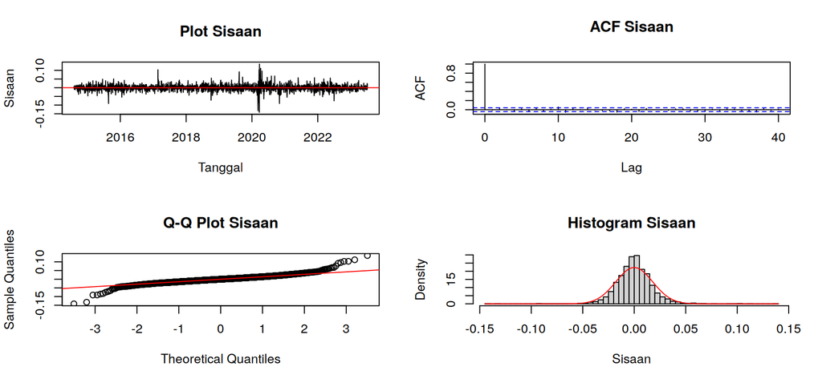

```r
sisa <- as.numeric(residuals(fit))
par(mfrow = c(2, 2))
plot(tgl_train, sisa, type = "l", xlab = "Tanggal", ylab = "Sisaan", main = "Plot Sisaan"); abline(h = 0, col = "red")
acf(sisa, lag.max = 40, main = "ACF Sisaan")
qqnorm(sisa, main = "Q-Q Plot Sisaan"); qqline(sisa, col = "red")
hist(sisa, breaks = 40, freq = FALSE, main = "Histogram Sisaan", xlab = "Sisaan")
curve(dnorm(x, mean(sisa), sd(sisa)), add = TRUE, col = "red")
```

```r
par(mfrow = c(1, 1))
```

```r
lb  <- Box.test(sisa, lag = 20, type = "Ljung-Box", fitdf = p_f + q_f)
sw  <- shapiro.test(sisa)
jb  <- jarque.bera.test(sisa)
tt  <- t.test(sisa, mu = 0)
arch <- Box.test(sisa^2, lag = 20, type = "Ljung-Box")

uji <- data.frame(
  Asumsi = c("Nilai tengah sisaan = 0", "Sisaan saling bebas (tak ada autokorelasi)",
             "Sisaan menyebar normal", "Sisaan menyebar normal",
             "Ragam sisaan homogen (tak ada efek ARCH)"),
  Uji = c("t-test", "Ljung-Box (lag 20)", "Shapiro-Wilk", "Jarque-Bera", "Ljung-Box pada sisaan kuadrat (lag 20)"),
  p_value = c(tt$p.value, lb$p.value, sw$p.value, jb$p.value, arch$p.value))
uji$Kesimpulan <- ket(uji$p_value)
uji$p_value <- fp(uji$p_value)
knitr::kable(uji, caption = "Hasil uji asumsi sisaan (taraf nyata 5%)")
```

Hasil uji asumsi sisaan (taraf nyata 5%)

| Asumsi | Uji | p_value | Kesimpulan |
| --- | --- | --- | --- |
| Nilai tengah sisaan = 0 | t-test | 0.9942 | terpenuhi (tak tolak H0) |
| Sisaan saling bebas (tak ada autokorelasi) | Ljung-Box (lag 20) | 0.0009 | tidak terpenuhi (tolak H0) |
| Sisaan menyebar normal | Shapiro-Wilk | < 0,0001 | tidak terpenuhi (tolak H0) |
| Sisaan menyebar normal | Jarque-Bera | < 0,0001 | tidak terpenuhi (tolak H0) |
| Ragam sisaan homogen (tak ada efek ARCH) | Ljung-Box pada sisaan kuadrat (lag 20) | < 0,0001 | tidak terpenuhi (tolak H0) |

```r
r_acf <- acf(sisa, plot = FALSE, lag.max = 20)$acf[-1]
r_maks <- max(abs(r_acf)); lag_maks <- which.max(abs(r_acf)); batas_acf <- 2 / sqrt(length(sisa))
lb_semua <- tabel$p_LjungBox_sisaan
```

**Interpretasi.**

- **Nilai tengah sisaan nol:** terpenuhi (tak tolak H0) (p-value 0.9942).
- **Autokorelasi:** tidak terpenuhi (tolak H0) (p-value Ljung-Box 0.0009). Autokorelasi sisaan secara statistik masih nyata karena jumlah amatan besar, tetapi nilainya sangat kecil (|r| terbesar = 0.059 pada lag 10, batas signifikansi = 0.043). Kolom p_LjungBox_sisaan pada tabel kandidat memperlihatkan hal yang sama untuk hampir semua model sederhana, sehingga menambah orde AR/MA tidak menyelesaikannya. Karena ramalan titik hampir tidak terpengaruh, model tetap dipakai dan hal ini dicatat sebagai keterbatasan (pola pada lag tertentu dapat dikaji lebih lanjut).
- **Kenormalan:** tidak terpenuhi (tolak H0). Q-Q plot memperlihatkan ekor yang lebih berat dari sebaran normal, hal yang lazim pada return saham harian karena adanya lonjakan harga ekstrem.
- **Homogenitas ragam:** tidak terpenuhi (tolak H0) (p-value < 0,0001). Bila tidak terpenuhi, ragam sisaan berubah menurut waktu (*volatility clustering*, misalnya saat gejolak pasar 2020). Pelanggaran ini tidak memengaruhi ramalan titik, tetapi selang ramalan menjadi kurang akurat. Model ARCH/GARCH dapat menjadi pengembangan lanjutan.

# 9 Overfitting

Model diperbesar satu orde pada AR atau MA, lalu diperiksa apakah parameter tambahan signifikan dan AIC membaik. Bila tidak, model terpilih **tidak overfit** dan cukup sederhana.

```r
cek_over <- function(p, q) {
  m <- Arima(ltrain, order = c(p, 1, q), include.drift = dr_f, method = "ML")
  ct <- tryCatch(suppressWarnings(coeftest(m)), error = function(e) NULL)
  nm <- if (q > q_f) paste0("ma", q) else paste0("ar", p)
  pv <- if (!is.null(ct) && nm %in% rownames(ct)) ct[nm, 4] else NA
  data.frame(Model = sprintf("ARIMA(%d,1,%d)%s", p, q, ifelse(dr_f, " + drift", "")),
             Parameter_tambahan = nm, p_value = round(pv, 4), AIC = round(AIC(m), 2),
             Signifikan = isTRUE(pv < 0.05), AIC_lebih_kecil = AIC(m) < AIC(fit))
}
over <- rbind(cek_over(p_f + 1, q_f), cek_over(p_f, q_f + 1))
over <- rbind(data.frame(Model = nama_terpilih, Parameter_tambahan = "-", p_value = NA,
                         AIC = round(AIC(fit), 2), Signifikan = NA, AIC_lebih_kecil = NA), over)
knitr::kable(over, caption = "Uji overfitting: model terpilih vs model satu orde lebih besar")
```

Uji overfitting: model terpilih vs model satu orde lebih besar

| Model | Parameter_tambahan | p_value | AIC | Signifikan | AIC_lebih_kecil |
| --- | --- | --- | --- | --- | --- |
| ARIMA(0,1,0) + drift | - | NA | -11452.32 | NA | NA |
| ARIMA(1,1,0) + drift | ar1 | 0.6186 | -11450.57 | FALSE | FALSE |
| ARIMA(0,1,1) + drift | ma1 | 0.6311 | -11450.55 | FALSE | FALSE |

Tidak ada parameter tambahan yang signifikan, sehingga penambahan orde tidak memberi perbaikan berarti. Model terpilih tidak mengalami overfitting.

# 10 Peramalan

Ramalan dibuat untuk 244 hari ke depan (sepanjang data uji) pada skala logaritma, lalu dikembalikan ke skala asli dengan $\hat{Y}_t = \exp(\hat{Z}_t)$. Sebagai pembanding digunakan model *naive* (ramalan = nilai terakhir data latih).

```r
fc <- forecast(fit, h = n_test, level = c(80, 95))
pred <- exp(as.numeric(fc$mean))
lo95 <- exp(as.numeric(fc$lower[, 2])); hi95 <- exp(as.numeric(fc$upper[, 2]))
lo80 <- exp(as.numeric(fc$lower[, 1])); hi80 <- exp(as.numeric(fc$upper[, 1]))
naive <- rep(tail(train, 1), n_test)

akurasi <- function(a, f) c(RMSE = sqrt(mean((a - f)^2)), MAE = mean(abs(a - f)), MAPE = mean(abs((a - f) / a)) * 100)
tab_ak <- rbind(akurasi(test, pred), akurasi(test, naive))
rownames(tab_ak) <- c(nama_terpilih, "Naive (nilai terakhir)")
knitr::kable(round(tab_ak, 2), caption = "Ukuran akurasi ramalan pada data uji (skala asli)")
```

Ukuran akurasi ramalan pada data uji (skala asli)

|  | RMSE | MAE | MAPE |
| --- | --- | --- | --- |
| ARIMA(0,1,0) + drift | 155.48 | 130.53 | 5.05 |
| Naive (nilai terakhir) | 342.03 | 273.11 | 9.65 |

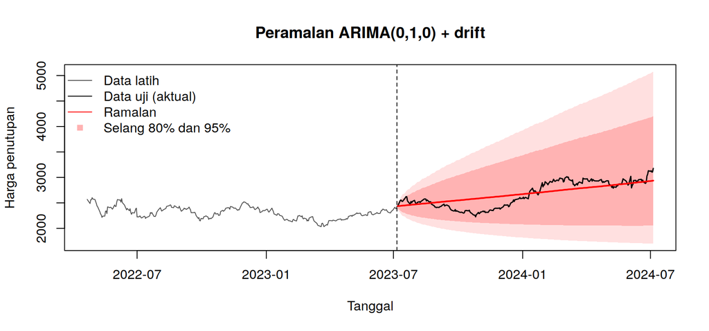

```r
tampil <- (n_train - 300):n_train
plot(c(tgl_train[tampil], tgl_test), c(train[tampil], test), type = "n",
     ylim = range(c(train[tampil], test, lo95, hi95)), xlab = "Tanggal", ylab = "Harga penutupan",
     main = paste("Peramalan", nama_terpilih))
polygon(c(tgl_test, rev(tgl_test)), c(lo95, rev(hi95)), col = rgb(1, 0, 0, 0.12), border = NA)
polygon(c(tgl_test, rev(tgl_test)), c(lo80, rev(hi80)), col = rgb(1, 0, 0, 0.20), border = NA)
lines(tgl_train[tampil], train[tampil], col = "grey30")
lines(tgl_test, test, col = "black", lwd = 1.5)
lines(tgl_test, pred, col = "red", lwd = 2)
abline(v = tgl[n_train], lty = 2)
legend("topleft", c("Data latih", "Data uji (aktual)", "Ramalan", "Selang 80% dan 95%"),
       col = c("grey30", "black", "red", rgb(1, 0, 0, 0.3)), lty = c(1, 1, 1, NA), pch = c(NA, NA, NA, 15), bty = "n")
```

Pada data uji, model menghasilkan **MAPE = 5.05%** dan RMSE = 155.48. Karena model terpilih bersifat *random walk* (dengan *drift*), ramalan berbentuk garis hampir lurus mengikuti *drift*, sehingga tidak dapat menangkap fluktuasi jangka pendek. Hal ini wajar karena harga saham yang efisien sulit diramalkan dari nilai masa lalunya. Ramalan ini lebih tepat dipandang sebagai arah umum dengan ketidakpastian yang melebar menurut waktu, sebagaimana terlihat pada selang kepercayaannya.

# 11 Kesimpulan

1. Data latih (2200 amatan) **tidak stasioner dalam rataan** (ACF turun lambat; ADF p-value = 0.0633) dan **tidak stasioner dalam ragam** (selang Box-Cox tidak memuat 1).
2. Ketidakstasioneran ditangani dengan **transformasi logaritma** dan *differencing* orde 1; setelah itu data stasioner (ADF p-value = 0.0100).
3. Berdasarkan ACF, PACF, EACF, signifikansi parameter, dan AIC, model terbaik adalah **ARIMA(0,1,0) + drift** pada data log harga.
4. Analisis sisaan: autokorelasi **tidak terpenuhi (tolak H0)**, kenormalan **tidak terpenuhi (tolak H0)**, dan homogenitas ragam **tidak terpenuhi (tolak H0)**.
5. Uji *overfitting* menunjukkan tidak ada parameter tambahan yang signifikan.
6. Pada data uji, model memberikan MAPE sebesar 5.05%.

*Catatan: seluruh keputusan statistik pada laporan ini dihitung otomatis dari data oleh kode R di dalamnya.*